# [Visualising]运用R绘制城市热点图

余文华

2016年2月20日

## 运用ggplot2包绘制热点图

- 我们的代码将包括以下步骤：
1. 读取数据

   我们将把数据转换为R可识别的格式。数据集中数据是字符串类别，我们运用strptime方法转换为我们需要的格式。
3. 按照时间排序

   我们希望按照周为单位展示热点图，探索机动车盗窃发生时间趋势。
4. 画热点图

   运用热点图展示在不同时间，机动车盗窃事件数量。

## 下面来实践下吧！

- 数据读取

```r
library(ggplot2)
#读取数据
chicagoMVTs <- read.csv("motor_vehicle_theft.csv",stringsAsFactors = FALSE)
set.seed(1234)
n <- sample(nrow(chicagoMVTs),20000,replace = FALSE)
chicagoMVT <- chicagoMVTs[n,]
head(chicagoMVT)
```

```
##                          Date                   Block        Primary.Type
## 31687  10/19/2012 10:00:00 PM    062XX N ST LOUIS AVE MOTOR VEHICLE THEFT
## 173421 04/30/2005 03:00:00 PM         027XX W 24TH PL MOTOR VEHICLE THEFT
## 169791 06/29/2005 12:30:00 AM    016XX W BLACKHAWK ST MOTOR VEHICLE THEFT
## 173721 04/25/2005 05:00:00 PM     048XX S WOLCOTT AVE MOTOR VEHICLE THEFT
## 239915 06/18/2002 04:00:00 PM 012XX N NORTH BRANCH ST MOTOR VEHICLE THEFT
## 178438 02/05/2005 04:00:00 AM     023XX S KOSTNER AVE MOTOR VEHICLE THEFT
##                            Description Location.Description Ward
## 31687                       AUTOMOBILE            RESIDENCE   50
## 173421                      AUTOMOBILE               STREET   12
## 169791 THEFT/RECOVERY: TRUCK,BUS,MHOME               STREET    1
## 173721                      AUTOMOBILE               STREET   20
## 239915                      AUTOMOBILE               STREET   32
## 178438                      AUTOMOBILE               STREET   22
##        Community.Area Year                      Location
## 31687              13 2012 (41.994489432, -87.716400573)
## 173421             30 2005 (41.847272952, -87.693406428)
## 169791             24 2005 (41.907129717, -87.667684971)
## 173721             61 2005 (41.806527547, -87.672354931)
## 239915              8 2002 (41.904325035, -87.655940608)
## 178438             29 2005 (41.848827114, -87.734278136)
```

- 数据转换

```r
#字符串转换为日期时间型格式
chicagoMVT$Date <- strptime(chicagoMVT$Date, format = "%m/%d/%Y %I:%M:%S")

#获得盗窃发生的日期和时间
chicagoMVT$Day <- weekdays(chicagoMVT$Date)
chicagoMVT$Hour <- chicagoMVT$Date$hour

#按照“周”为单位排序
dailyCrimes <- as.data.frame(table(chicagoMVT$Day, chicagoMVT$Hour))
names(dailyCrimes) <- c('Day', 'Hour', 'Freq')
dailyCrimes$Hour <- as.numeric(as.character(dailyCrimes$Hour))
dailyCrimes$Day <- factor(dailyCrimes$Day, ordered = TRUE,
                         levels = c('星期日', '星期一', '星期二', '星期三', '星期四', '星期五', '星期六'))
```

- 盗窃发生时间趋势图

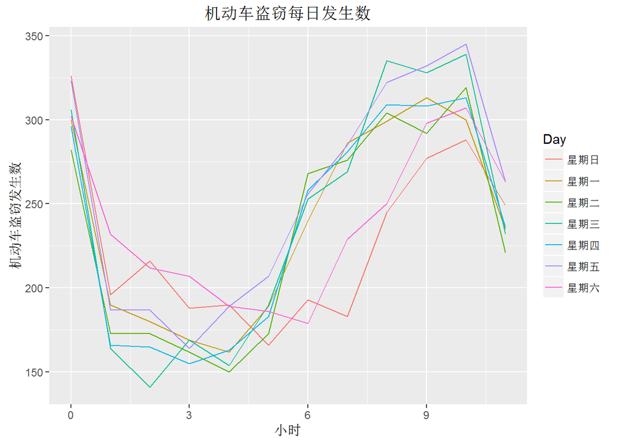

[output not shown]

```r
library(ggplot2)
ggplot(dailyCrimes,aes(x = Hour, y = Freq))+geom_line(aes(group = Day, color = Day)) +xlab("小时") +ylab("机动车盗窃发生数") +ggtitle("机动车盗窃每日发生数")
```

- 热点图

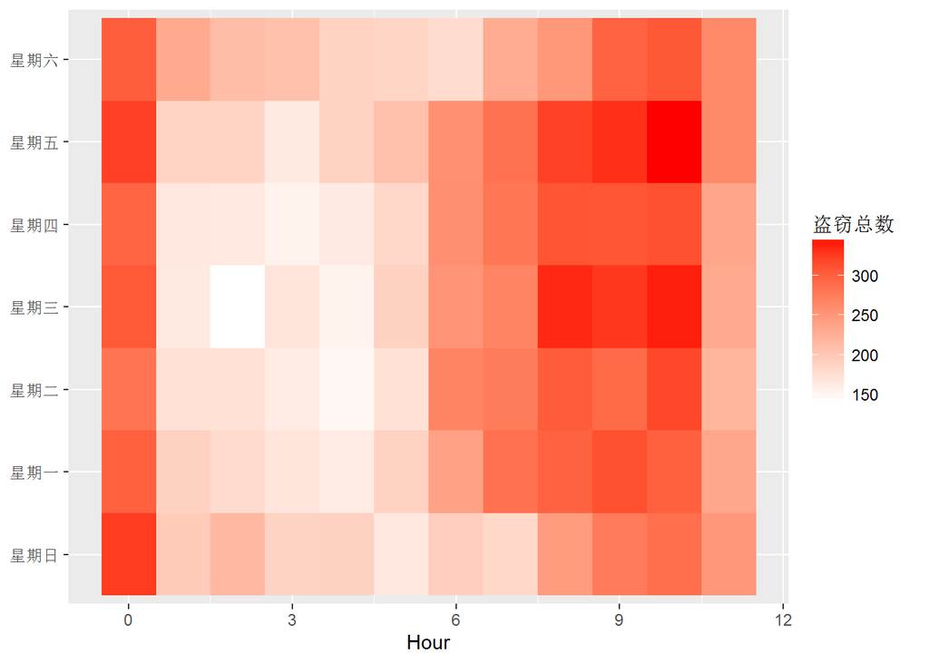

```r
ggplot(dailyCrimes, aes( x = Hour, y = Day)) +
        geom_tile(aes(fill = Freq)) +
        scale_fill_gradient(name = "盗窃总数",low ="white", high = "red" )+
        theme(axis.title.y = element_blank())
```

## 在地图上绘制热点图

```
前面已经讨论了如何用ggplot绘制热点图，现在让我们来看看如何用R包在地图上绘制热点图。我们需要2个R包：maps包和ggmap包。为了数据清洗，我们还用到了dplyr包和tidyr包。
```

- 地图上绘制热点图的步骤：
1. 删除盗窃地址为空的数据。对于许多盗窃事件，地址信息并没有记录，这种删失被称为右删失，即这种删失有一定的原因，具有非随机性。
2. 把location列分解为latitu（维度）和longitude（经度）。location列以（x,y）形式构成，属于字符串类型。为们需要x，y称为独立的两列，同时为数值型。这时我们用到了dplyr和tidyr。
3. 获取芝加哥地图。这时用到了ggmap包。
4. 画位置地图热点图
- 下面来看代码：
- 删除location列为空的数据行

```r
chicagoMVT$Location[chicagoMVT$Location ==""] <- NA
chicagoMVT <- na.omit(chicagoMVT)
nrow(chicagoMVT)
```

```
## [1] 17490
```

[output not shown]

- 把location列分解为latitu（纬度）和longitude（经度）

```r
library(dplyr)
library(tidyr)
chicagoMVT <- extract(chicagoMVT,Location,c("Latitude","Longitude"),'\\(([^,]+),([^)]+)\\)')
chicagoMVT$Latitude <- round(as.numeric(chicagoMVT$Latitude),2)
chicagoMVT$Longitude <- round(as.numeric(chicagoMVT$Longitude), 2)
```

```
extract函数来自于tidyr包，用于“提取一列到多列”。这里用于分离Location列为“Latitude”和“Longitude”列，最后一个参数为正则表达式（Regular Expression or RegEx for short）。
```